# Project 1:

## Visual Narratives With Code

### Dataset:

https://www.kaggle.com/datasets/yashdevladdha/uber-ride-analytics-dashboard

I chose this dataset because it seemed interesting and it was the first one I came across.

Columns:

```
Date - Date of the booking
Time - Time of the booking
Booking ID - Unique identifier for each ride booking
Booking Status - Status of booking (Completed, Cancelled by Customer, Cancelled by Driver, etc.)
Customer ID - Unique identifier for customers
Vehicle Type - Type of vehicle (Go Mini, Go Sedan, Auto, eBike/Bike, UberXL, Premier Sedan)
Pickup Location - Starting location of the ride
Drop Location - Destination location of the ride
Avg VTAT - Average time for driver to reach pickup location (in minutes)
Avg CTAT - Average trip duration from pickup to destination (in minutes)
Cancelled Rides by Customer - Customer-initiated cancellation flag
Reason for cancelling by Customer - Reason for customer cancellation
Cancelled Rides by Driver - Driver-initiated cancellation flag
Driver Cancellation Reason - Reason for driver cancellation
Incomplete Rides - Incomplete ride flag
Incomplete Rides Reason - Reason for incomplete rides
Booking Value - Total fare amount for the ride
Ride Distance - Distance covered during the ride (in km)
Driver Ratings - Rating given to driver (1-5 scale)
Customer Rating - Rating given by customer (1-5 scale)
Payment Method - Method used for payment (UPI, Cash, Credit Card, Uber Wallet, Debit Card)
```

## Imports

Standard Python libraries for data visualization.

```python
import numpy as np
import pandas as pd
import matplotlib.pyplot as plt
import seaborn as sns
```

## Dataset Introduction

```python
df = pd.read_csv('Dataset/ncr_ride_bookings.csv')
df.head()
```

|  | Date | Time | Booking ID | Booking Status | Customer ID | Vehicle Type | Pickup Location | Drop Location | Avg VTAT | Avg CTAT | ... | Reason for cancelling by Customer | Cancelled Rides by Driver | Driver Cancellation Reason | Incomplete Rides | Incomplete Rides Reason | Booking Value | Ride Distance | Driver Ratings | Customer Rating | Payment Method |
| --- | --- | --- | --- | --- | --- | --- | --- | --- | --- | --- | --- | --- | --- | --- | --- | --- | --- | --- | --- | --- | --- |
| 0 | 2024-03-23 | 12:29:38 | "CNR5884300" | No Driver Found | "CID1982111" | eBike | Palam Vihar | Jhilmil | NaN | NaN | ... | NaN | NaN | NaN | NaN | NaN | NaN | NaN | NaN | NaN | NaN |
| 1 | 2024-11-29 | 18:01:39 | "CNR1326809" | Incomplete | "CID4604802" | Go Sedan | Shastri Nagar | Gurgaon Sector 56 | 4.9 | 14.0 | ... | NaN | NaN | NaN | 1.0 | Vehicle Breakdown | 237.0 | 5.73 | NaN | NaN | UPI |
| 2 | 2024-08-23 | 08:56:10 | "CNR8494506" | Completed | "CID9202816" | Auto | Khandsa | Malviya Nagar | 13.4 | 25.8 | ... | NaN | NaN | NaN | NaN | NaN | 627.0 | 13.58 | 4.9 | 4.9 | Debit Card |
| 3 | 2024-10-21 | 17:17:25 | "CNR8906825" | Completed | "CID2610914" | Premier Sedan | Central Secretariat | Inderlok | 13.1 | 28.5 | ... | NaN | NaN | NaN | NaN | NaN | 416.0 | 34.02 | 4.6 | 5.0 | UPI |
| 4 | 2024-09-16 | 22:08:00 | "CNR1950162" | Completed | "CID9933542" | Bike | Ghitorni Village | Khan Market | 5.3 | 19.6 | ... | NaN | NaN | NaN | NaN | NaN | 737.0 | 48.21 | 4.1 | 4.3 | UPI |

5 rows × 21 columns

```python
df.shape
```

```
(150000, 21)
```

## Preprocessing

First step of my preprocessing I wanted to focus on a specific subset of variables and decided on: Booking Status, Vehicle Type, Reason for cancelling by Customer, Cancelled Rides by Driver, Driver Cancellation Reason, Incomplete Rides Reason, Customer Rating. I am also looking at some of these variables in relation to time and date. There are a lot of missing values in this dataset but not in the way that it would take away from the meaning of the visualizations and all of the visuals automatically drop NAN values. A lot of the missing values are caused by values not being provided to Uber from the driver or customer.

```python
cols_to_check = ["Booking Status", "Vehicle Type", "Reason for cancelling by Customer", "Cancelled Rides by Driver", "Driver Cancellation Reason", "Incomplete Rides Reason", "Customer Rating"]

for col in cols_to_check:
    print(f"\n\tValue counts for '{col}':")
    print(df[col].value_counts())
    print("Null Values: " , df[col].isnull().sum())
```

```
	Value counts for 'Booking Status':
Booking Status
Completed                93000
Cancelled by Driver      27000
No Driver Found          10500
Cancelled by Customer    10500
Incomplete                9000
Name: count, dtype: int64
Null Values:  0

	Value counts for 'Vehicle Type':
Vehicle Type
Auto             37419
Go Mini          29806
Go Sedan         27141
Bike             22517
Premier Sedan    18111
eBike            10557
Uber XL           4449
Name: count, dtype: int64
Null Values:  0

	Value counts for 'Reason for cancelling by Customer':
Reason for cancelling by Customer
Wrong Address                                   2362
Change of plans                                 2353
Driver is not moving towards pickup location    2335
Driver asked to cancel                          2295
AC is not working                               1155
Name: count, dtype: int64
Null Values:  139500

	Value counts for 'Cancelled Rides by Driver':
Cancelled Rides by Driver
1.0    27000
Name: count, dtype: int64
Null Values:  123000

	Value counts for 'Driver Cancellation Reason':
Driver Cancellation Reason
```

[output cut: 25 more lines]

```
4.1     5396
4.4     5279
3.9     2370
3.8     2357
3.7     2354
3.6     1194
4.0     1185
3.1     1008
3.4      928
3.3      900
3.2      881
3.0      468
3.5      443
Name: count, dtype: int64
Null Values:  57000
```

## Time Analysis

### Rides separated by Booking Status

In the first visualization I want to look at is when during the day the most rides were scheduled. The visualization shows a peak at around 10:20 and 18:40 since this variable was tracked using a 24-hour clock. This is equivalent to 10:20AM and 6:40PM on the 12-hour clock. We see that the other Booking Statuses follow a similar peak pattern.

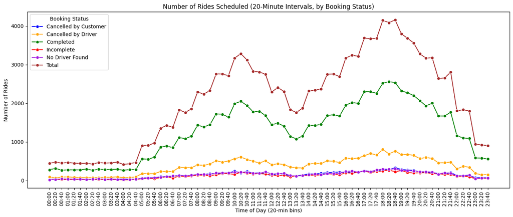

```python
status_colors = {
    "Total": "brown",
    "Completed": "green",
    "Cancelled by Customer": "blue",
    "Cancelled by Driver": "orange",
    "Incomplete": "red",
    "No Driver Found": "#A219E1"
}

# Convert Time column to datetime
df["Time"] = pd.to_datetime(df["Time"], format="%H:%M:%S", errors="coerce")

# Round down to nearest 20 minutes
df["Time_20min"] = df["Time"].dt.floor("20min").dt.strftime("%H:%M")

# Count rides by 20-min interval and Booking Status
status_counts = df.groupby(["Time_20min", "Booking Status"]).size().reset_index(name="Number of Rides")

# Also calculate total rides regardless of status
total_counts = df.groupby("Time_20min").size().reset_index(name="Number of Rides")
total_counts["Booking Status"] = "Total"  # Add label so we can plot it together

# Combine into one DataFrame
plot_df = pd.concat([status_counts, total_counts])

# Plot
plt.figure(figsize=(14,6))
sns.lineplot(data=plot_df, x="Time_20min", y="Number of Rides", hue="Booking Status", palette=status_colors, marker="o")

plt.xticks(rotation=90)
plt.title("Number of Rides Scheduled (20-Minute Intervals, by Booking Status)")
plt.xlabel("Time of Day (20-min bins)")
plt.ylabel("Number of Rides")
plt.tight_layout()
plt.show()
```

### Separated by Booking Status with a focus on cancelled/incomplete rides

For this visualization I wanted to focus on the lower portion of the above visual

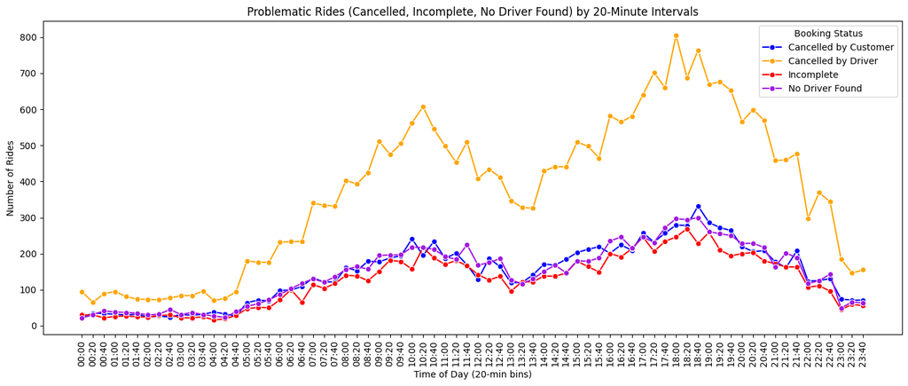

```python
# Define the statuses we care about
problem_statuses = ["Cancelled by Customer", "Cancelled by Driver", "Incomplete", "No Driver Found"]

# Filter dataset
problem_df = df[df["Booking Status"].isin(problem_statuses)]

# Count rides by 20-min interval and Booking Status
problem_counts = (
    problem_df.groupby(["Time_20min", "Booking Status"])
    .size()
    .reset_index(name="Number of Rides")
)

# Plot
plt.figure(figsize=(14,6))
sns.lineplot(
    data=problem_counts,
    x="Time_20min",
    y="Number of Rides",
    hue="Booking Status",
    palette=status_colors,
    marker="o"
)

plt.xticks(rotation=90)
plt.title("Problematic Rides (Cancelled, Incomplete, No Driver Found) by 20-Minute Intervals")
plt.xlabel("Time of Day (20-min bins)")
plt.ylabel("Number of Rides")
plt.tight_layout()
plt.show()
```

## Value Counts Distributions

In this section I look at the distribution of each value of the columns mentioned above. All functions leave out null values for those that have it which are all but the first two visuals.

### Booking Status

Looks at the percent distribution of booking statuses.

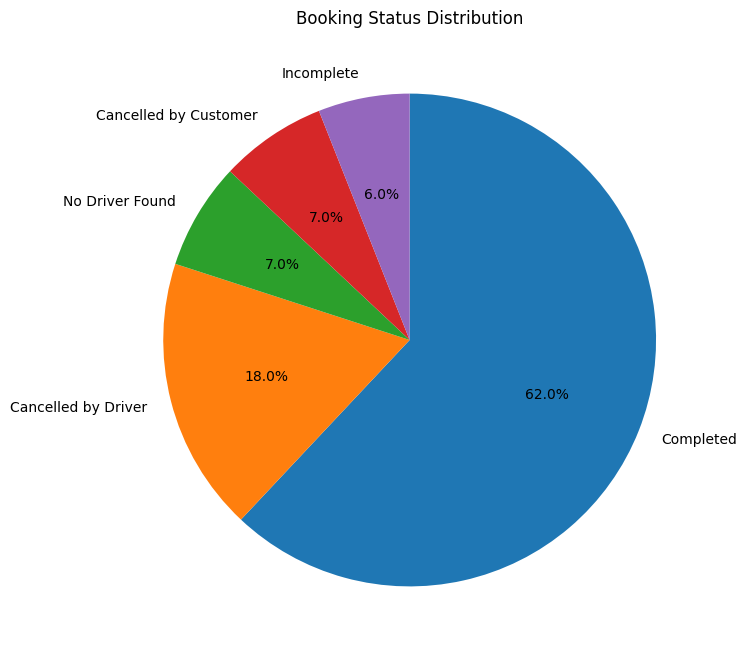

```python
status_counts = df["Booking Status"].value_counts()

plt.figure(figsize=(8,8))
plt.pie(
    status_counts,
    labels=status_counts.index,
    autopct="%1.1f%%",
    startangle=90,
    counterclock=False
)

plt.title("Booking Status Distribution")
plt.show()
```

### Vehicle Type

Looks at the percent distribution of Uber vehicle types.

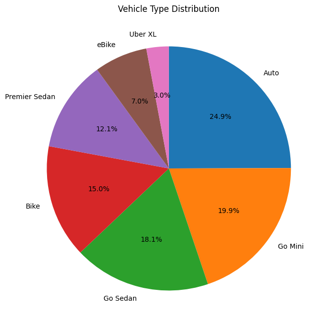

```python
status_counts = df["Vehicle Type"].value_counts()

plt.figure(figsize=(8,8))
plt.pie(
    status_counts,
    labels=status_counts.index,
    autopct="%1.1f%%",
    startangle=90,
    counterclock=False
)

plt.title("Vehicle Type Distribution")
plt.show()
```

### Reason for cancalling by Customer

Looks at the distribution of reasons the customer cancelled the ride. Only uses the ones with values which means these can be seen as a % of the cancelled by customer booking status.

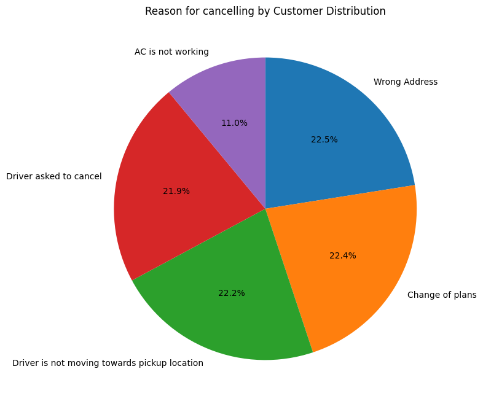

```python
status_counts = df["Reason for cancelling by Customer"].value_counts()

plt.figure(figsize=(8,8))
plt.pie(
    status_counts,
    labels=status_counts.index,
    autopct="%1.1f%%",
    startangle=90,
    counterclock=False
)

plt.title("Reason for cancelling by Customer Distribution")
plt.show()
```

### Driver Cancellation Reason

Similar to the visual above, this only looks at the rides cancelled by the driver.

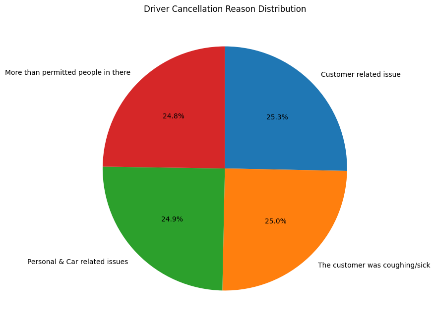

```python
status_counts = df["Driver Cancellation Reason"].value_counts()

plt.figure(figsize=(8,8))
plt.pie(
    status_counts,
    labels=status_counts.index,
    autopct="%1.1f%%",
    startangle=90,
    counterclock=False
)

plt.title("Driver Cancellation Reason Distribution")
plt.show()
```

### Incomplete Rides Reason

Similar to the one above this only looks at incomplete rides

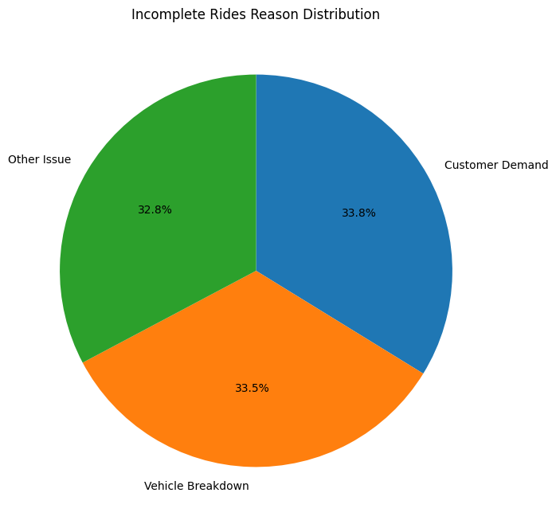

```python
status_counts = df["Incomplete Rides Reason"].value_counts()

plt.figure(figsize=(8,8))
plt.pie(
    status_counts,
    labels=status_counts.index,
    autopct="%1.1f%%",
    startangle=90,
    counterclock=False
)

plt.title("Incomplete Rides Reason Distribution")
plt.show()
```

### Customer Rating

The first visual under this section looks at the distribution of customer ratings as a histogram. The next 4 look at the average customer rating across the year split into quarters. There is also a line showing the max, min, and average rating for each quarter.

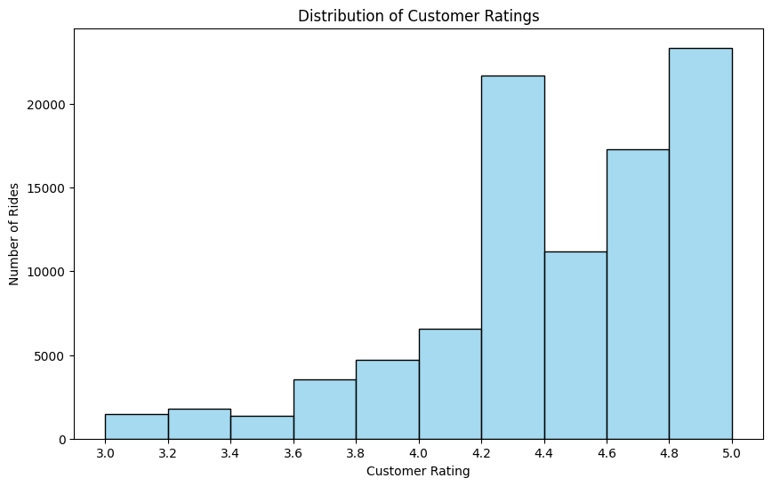

```python
plt.figure(figsize=(10,6))

# Create evenly spaced bins between min and max
bin_edges = np.linspace(df["Customer Rating"].min(), df["Customer Rating"].max(), 11)

sns.histplot(
    df["Customer Rating"].dropna(),
    bins=bin_edges,
    color="skyblue",
    edgecolor="black"
)

plt.title("Distribution of Customer Ratings")
plt.xlabel("Customer Rating")
plt.ylabel("Number of Rides")
plt.xticks(bin_edges, rotation=0)
plt.show()
```

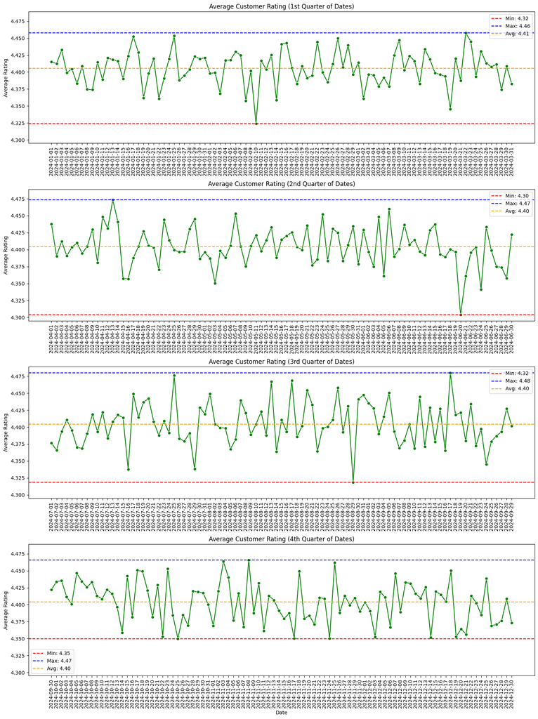

```python
ratings_over_time = df.groupby("Date")["Customer Rating"].mean().reset_index()

# Determine split points
n = len(ratings_over_time)
q1 = n // 4
q2 = n // 2
q3 = 3 * n // 4

# Create 4 subplots (stacked vertically)
fig, axes = plt.subplots(4, 1, figsize=(15, 20), sharey=True)

quarters = [
    ratings_over_time.iloc[:q1],
    ratings_over_time.iloc[q1:q2],
    ratings_over_time.iloc[q2:q3],
    ratings_over_time.iloc[q3:]
]

titles = [
    "Average Customer Rating (1st Quarter of Dates)",
    "Average Customer Rating (2nd Quarter of Dates)",
    "Average Customer Rating (3rd Quarter of Dates)",
    "Average Customer Rating (4th Quarter of Dates)"
]

# Plot each quarter
for i, (data, title) in enumerate(zip(quarters, titles)):
    sns.lineplot(data=data, x="Date", y="Customer Rating",
                 marker="o", color="green", ax=axes[i])

    # Get min, max, mean for this quarter
    y_min = data["Customer Rating"].min()
    y_max = data["Customer Rating"].max()
    y_mean = data["Customer Rating"].mean()

    # Add reference lines
    axes[i].axhline(y=y_min, color="red", linestyle="--", label=f"Min: {y_min:.2f}")
    axes[i].axhline(y=y_max, color="blue", linestyle="--", label=f"Max: {y_max:.2f}")
    axes[i].axhline(y=y_mean, color="orange", linestyle="--", label=f"Avg: {y_mean:.2f}")

    # Titles & labels
    axes[i].set_title(title)
    axes[i].set_ylabel("Average Rating")
    axes[i].tick_params(axis="x", rotation=90)
    if i < 3:
        axes[i].set_xlabel("")
    else:
        axes[i].set_xlabel("Date")

    axes[i].legend()

plt.tight_layout()
plt.show()
```

## Reflection:

I feel like I made the best visual choice for each area I wanted to cover even with the amount of null values in the dataset. Something I would change is maybe make more time based visualizations and if the project called for it I would like to have taken a more machine learning based analysis into the dataset.